# Goodness-of-Fit

Econometrics - ECON 426

## Introduction

## Overview

In this tutorial, we will assess Goodness-of-Fit via the coefficient of determination.

## Importing data into R

For this lecture, we will be using the `food` data from PoE data set that can be found at http://www.principlesofeconometrics.com/poe5/poe5data.html.

```r
food <- read.csv("data/food.csv")
```

Estimate the linear model

```r
mod1 <- lm(food_exp ~ income, data = food)
```

## All about \(R^2\)

## The coefficient of determination

- \(R^2\), is defined as the proportion of the variance in \(y\) that is explained by the regression and the total variation in \(y\).
- \(R^2\) is displayed in the model summary and is labeled “Multiple R-squared”

```r
summary(mod1)
```

```
Call:
lm(formula = food_exp ~ income, data = food)

Residuals:
     Min       1Q   Median       3Q      Max
-223.025  -50.816   -6.324   67.879  212.044

Coefficients:
            Estimate Std. Error t value Pr(>|t|)
(Intercept)   83.416     43.410   1.922   0.0622 .
income        10.210      2.093   4.877 1.95e-05 ***
---
Signif. codes:  0 '***' 0.001 '**' 0.01 '*' 0.05 '.' 0.1 ' ' 1

Residual standard error: 89.52 on 38 degrees of freedom
Multiple R-squared:  0.385, Adjusted R-squared:  0.3688
F-statistic: 23.79 on 1 and 38 DF,  p-value: 1.946e-05
```

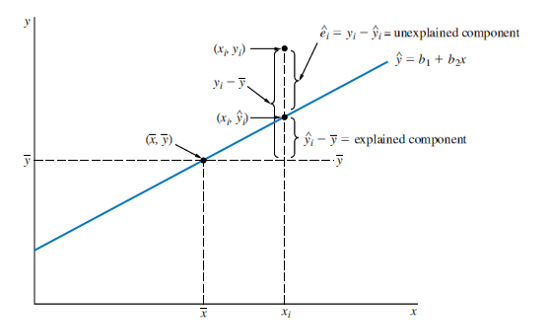

## Warning about \(R^2\)

- \(R^2\) is neither the only measure of goodness-of-fit nor is it a sufficient measure.
- It is a usefully statistic, but it has it limitations.
- \(R^2\) is increasing in the number of parameters in the model.

## Adjusted \(R^2\)

- Adjusted \(R^2\) attempts to fix this by adding a penalty for adding lees statistical significant independent variables
- adjusted \(R^2\) is not a measure of goodness-of-fit, but rather a model selection criteria, but it is not a very good one.
- Moreover, \(R^2\) is not a substitute for plotting the data as was shown a statistician named Anscombe.

## Anscombe’s Quartet

```r
data("anscombe")
describe(anscombe, skew = F,ranges = F)
```

|  | vars | n | mean | sd | se |
| --- | --- | --- | --- | --- | --- |
| x1 | 1 | 11 | 9.000000 | 3.316625 | 1.0000000 |
| x2 | 2 | 11 | 9.000000 | 3.316625 | 1.0000000 |
| x3 | 3 | 11 | 9.000000 | 3.316625 | 1.0000000 |
| x4 | 4 | 11 | 9.000000 | 3.316625 | 1.0000000 |
| y1 | 5 | 11 | 7.500909 | 2.031568 | 0.6125408 |
| y2 | 6 | 11 | 7.500909 | 2.031657 | 0.6125676 |
| y3 | 7 | 11 | 7.500000 | 2.030424 | 0.6121958 |
| y4 | 8 | 11 | 7.500909 | 2.030578 | 0.6122425 |

## Anscombe’s Quartet Plotted

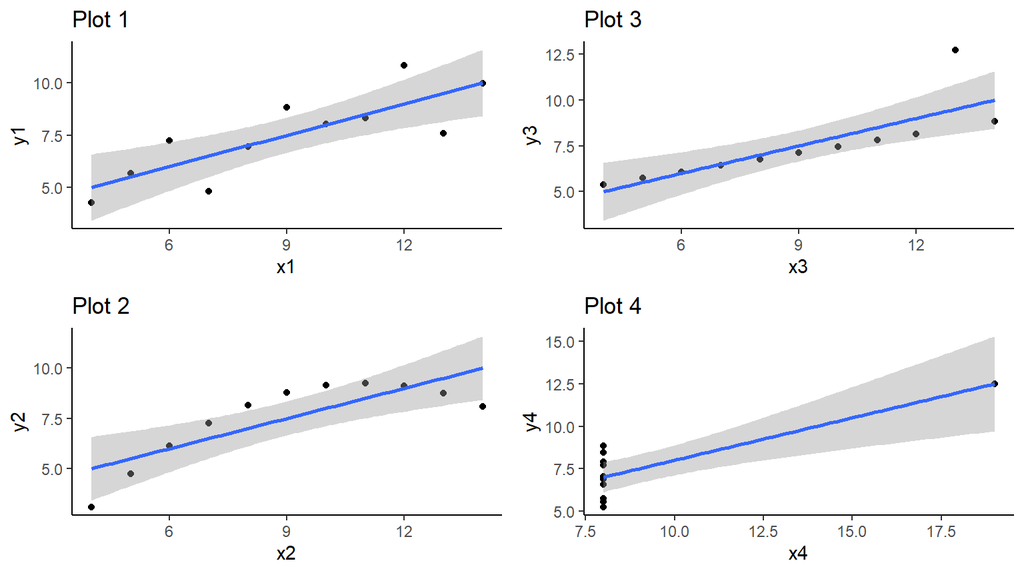

## You did it!